# Philadelphia Population Density: 3D Visualizations

Macy Trout

2024-12-02

The 3D population density map builds upon the 2D visualization by adding a vertical dimension to represent density dynamically. This approach emphasizes population density differences across Census tracts in a visually compelling way, allowing viewers to intuitively grasp the variation in density across Philadelphia. The added height provides a more engaging perspective compared to the static 2D map.

**Design Considerations**

Perspective:

- The map is rendered with a horizontal rotation (theta = 45°) and vertical tilt (phi = 45°), providing a balanced and clear perspective.
- These settings ensure that viewers can perceive the relative height differences across the city without obscuring the details.

Height Exaggeration:

- The vertical scale (scale = 350) was carefully chosen to emphasize density variations between tracts. This ensures that even smaller differences are noticeable while keeping the proportions realistic.

Shadows:

- A sun angle of 240° casts dynamic shadows, adding depth and contrast to the visualization, making it easier to distinguish between areas with similar heights.

Color Palette:

- The magma color palette, consistent with the 2D map, uses a gradient from deep purple to bright orange to reflect density values. The vibrant contrast ensures high-density areas stand out prominently.

**Outcome**

The 3D map effectively highlights high-density areas such as Center City, parts of West Philadelphia, and other urban cores. The dynamic perspective draws attention to the stark contrasts between dense and sparse regions, creating a powerful tool for understanding spatial population distribution.

This visualization combines aesthetics and functionality, offering a deeper, more intuitive understanding of Philadelphia’s population density patterns. It is well-suited for presentations, reports, or engaging stakeholders in discussions about urban density and planning.

```r
library(sf)
library(dplyr)
library(tidycensus)
library(sf)
library(ggplot2)
library(rayshader)
library(showtext)
library(dplyr)
library(rgl)

philly_data <- st_read("/Users/macytrout/Desktop/philadelphia.geojson", quiet=TRUE)
```

```r
philly_census <- suppressMessages(
  get_acs(
    geography = "tract",
    variables = c(population = "B01003_001"),
    state = "PA",
    county = "Philadelphia",
    geometry = TRUE,
    year = 2020
  )
)


philly_census <- philly_census %>%
  st_transform(crs = "+proj=longlat +datum=WGS84") %>%
  mutate(
    area_km2 = st_area(geometry) / 1e6,
    pop_density = estimate / as.numeric(area_km2)

)
```

```r
library(viridis)

font <- "Advent Pro"
font_add_google(font)
showtext_auto()

p <- ggplot() +
  geom_sf(data = philly_census, aes(fill = pop_density), color = NA) +
  scale_fill_viridis_c(
    option = "magma",
    trans = "log",
    name = "Population Density\n(people/km²)",
    labels = scales::comma
  ) +
  theme_void() +
  theme(
    legend.position = "bottom",
    legend.title = element_text(size = 12, face = "bold", family = font),
    legend.text = element_text(size = 10, family = font),
    plot.background = element_rect(fill = "#f0f0f0", color = NA)
  )
```

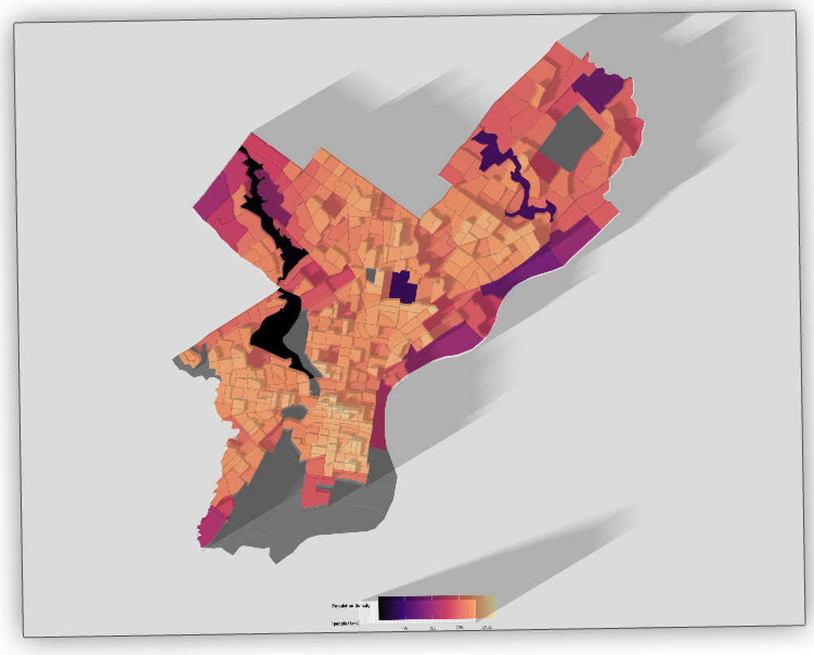

[figure not shown]

```r
library(rgl)

plot_gg(
  p,
  multicore = TRUE,
  width = 8,
  height = 6.285714,
  zoom = 0.8,
  sunangle = 240,
  theta = 45,
  phi = 45,
  solidcolor = "white",
  verbose = TRUE,
  windowsize = c(1400, 866),
  scale = 350,
  raytrace = TRUE,
  triangulate = TRUE
)
# code for rendering the 3D MAP below...

# render_highquality("philly_3D_population_density_refined.png", samples = 300)
```